# Lecture 08 playground

```r
library(tidyverse)
library(car)
library(performance)
library(patchwork)
```

# Assumptions

## Simulate non-linearity (quadratic)

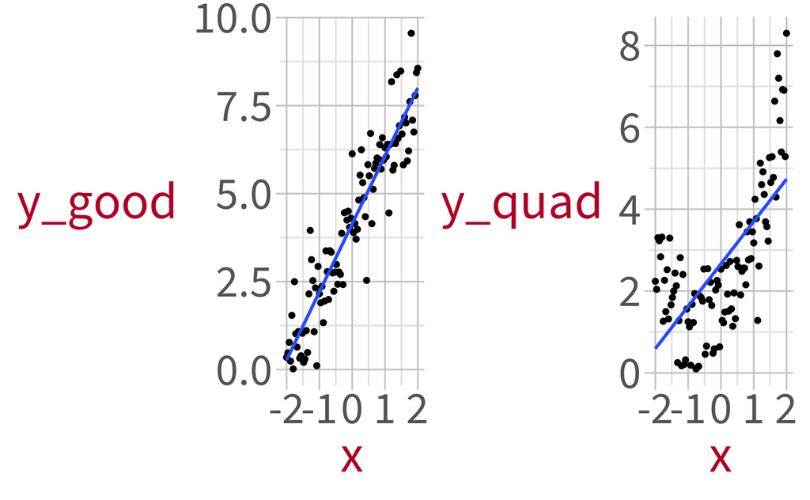

```r
set.seed(221020)
quadr <- function(x, a, b, c){ a + b*x + c*x^2  }

df <- tibble(
  x = seq(-2, 2, length.out = 101),
  y_good = abs(4 + (2 * x) + rnorm(101, 0, 1)),
  y_quad = abs(quadr(x + 0.5, 1, 0, 1) + rnorm(101, 0, 1)),
)

p_good <- df %>%
  ggplot(aes(x=x, y=y_good)) +
  geom_point() +
  geom_smooth(method = 'lm', se = FALSE) +
  NULL

p_quad <- df |>
  ggplot(aes(x=x, y=y_quad)) +
  geom_point() +
  geom_smooth(method = 'lm', se = FALSE) +
  NULL

p_good + p_quad
```

### check with component residual plots

component = the individual association of a particular predictor and the outcome, with all the other predictors held constant.

residual = the differences between the line the model predicts and the actual observed data points.

```r
df
```

| x | y_good | y_quad |
| --- | --- | --- |
| -2.00 | 0.347 | 2.2377 |
| -1.96 | 0.476 | 2.0419 |
| -1.92 | 0.772 | 3.3028 |
| -1.88 | 0.239 | 3.2281 |
| -1.84 | 1.540 | 2.8372 |
| -1.80 | 0.019 | 3.3166 |
| -1.76 | 2.496 | 1.2612 |
| -1.72 | 1.017 | 2.2620 |
| -1.68 | 0.640 | 1.4971 |
| -1.64 | 1.080 | 2.5208 |

[output cut: 91 more lines]

```r
NA
NA
```

## Simulate autocorrelated errors

> If you roll a 6-sided die at 9am everyday, you’ll find there is no correlation from one day to the next. Every time you roll the die you’ll get a completely random number coming from the die. If you look at the temperature at 9am everyday, you will notice that days tend to be correlated with adjacent days. If it’s 10 degrees on Monday, it’s far more likely to be 0-20 degrees on Tuesday than it is to be -20 degrees or 50 degrees. Even though it might be quite common to have a 50 degree morning, the previous data suggests it probably won’t be.

Probably needlessly complex, esp with so much other stuff to cover. Worth mentioning conceptually but not belabouring.

```r
# source: https://stackoverflow.com/a/77090029

acf.negbin <- function(N, mu, size, alpha, max.iter = 100, tol = 1e-5) {

  m = length(alpha)

  generate = function(){
   x = sort(rnbinom(N,size=size,mu=mu))
   y <- rnorm(length(x))
   x[rank(stats::filter(y, alpha, circular = TRUE))]
  }

  a = generate()
  iter <- 0L

  ACF <- function(x) acf(x, lag.max = m - 1, plot = FALSE)$acf[1:m]
  SSE <- function(x,alpha) sum((ACF(x) - alpha)^2)

  while ((SSE0 <- SSE(a, alpha)) > tol) {
    if ((iter <- iter + 1L) == max.iter) break
    a1 <- generate()
    if(SSE(a1,alpha) < SSE0) a <- a1
  }

  return(a)

}
```

```r
set.seed(2023)
acf_hi = acf.negbin(
  30,            # how many obs to simulate
  mu = 10,      # mean of simulated data
  size = 5,     # dispersion parameter.
                  # the bigger, the tighter the data will cluster around the mean.
  # alpha=c(1,0.5)  # ? correl of points with lag = 1 and lag = 2
  alpha=c(0.9, 0.8, 0.8, 0.8)  # ? correl of points with lag = 1 and lag = 2
  )

acf_hi
```

```
 [1] 13  5 10  9  5  7  5  4  5  6  7  5  5  6  7  7 10 10 11 15 12 21 17 21 23 16 11 13  9 11
```

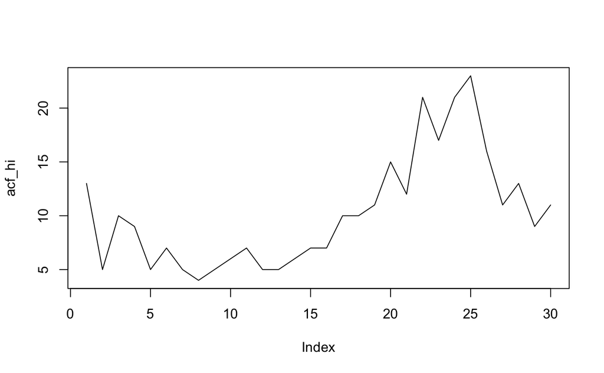

```r
plot(acf_hi,type='l')
```

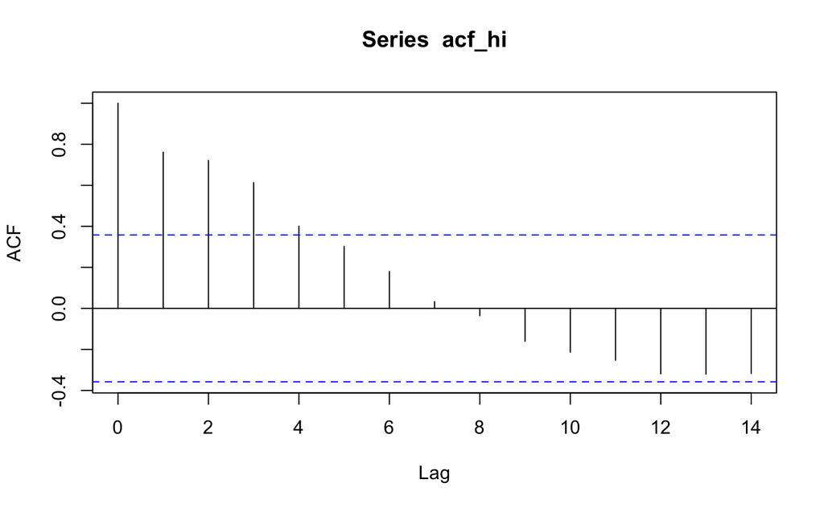

```r
# mean(x)
acf(acf_hi)#acf[1:2]
```

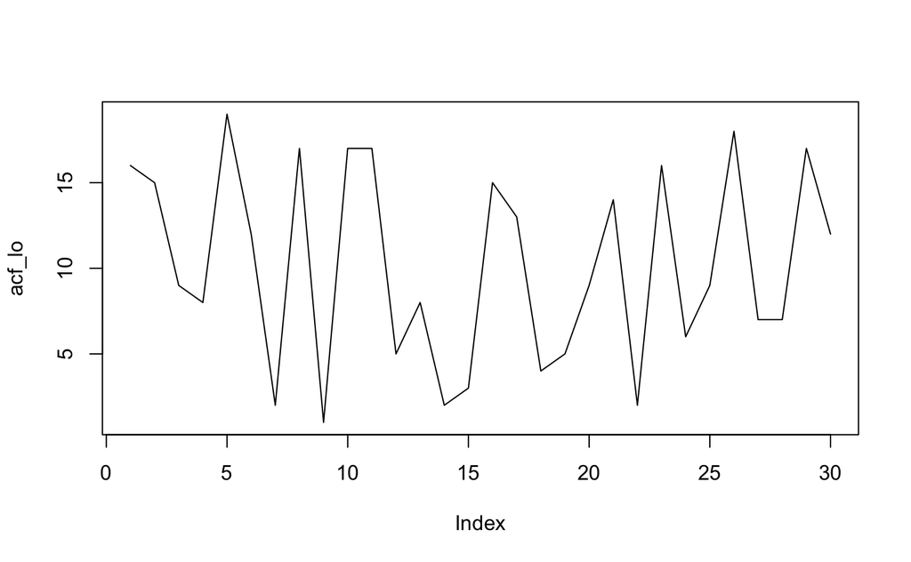

```r
set.seed(2023)
acf_lo <- sample(1:20, size = 30, replace = TRUE)

plot(acf_lo, type='l')
```

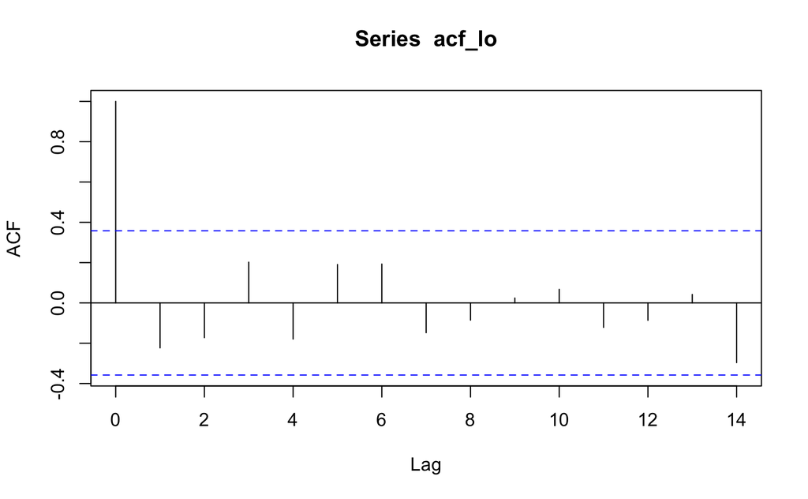

```r
acf(acf_lo)
```

## Simulate non-normal errors

Let’s try generating non-normal errors by sampling from an asymmetrical beta distribution. Centre those estims on zero and then use them as errors. So it’ll be normal in that the mean is zero, but they’ll be super skewed.

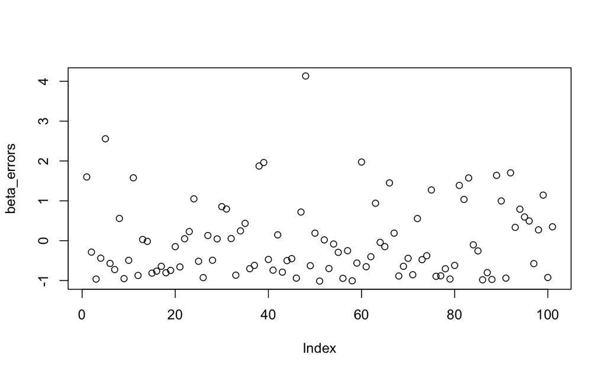

```r
set.seed(1)
beta_errors <- rbeta(101, shape1 = 1, shape2 = 50) |>
  scale(scale = FALSE, center = TRUE) * 50
plot(beta_errors)
```

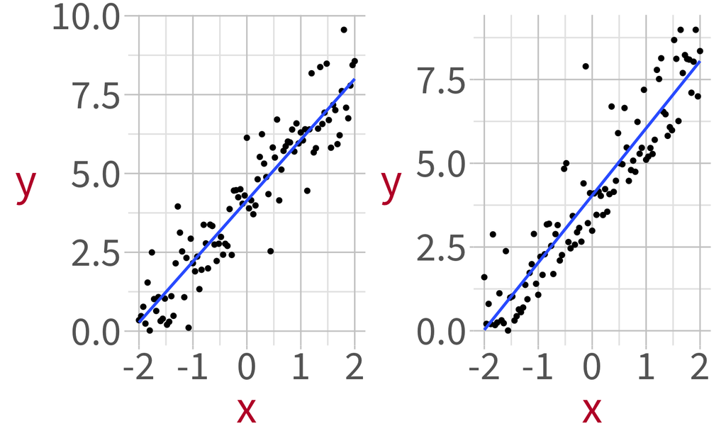

```r
set.seed(221020)

df <- tibble(
  x = seq(-2, 2, length.out = 101),
  y_good = abs(4 + (2 * x) + rnorm(101, 0, 1)),
  y_beta = abs(4 + (2 * x) + beta_errors),

  # y_quad = abs(quadr(x + 0.5, 1, 0, 1) + rnorm(101, 0, 1)),
)
# df2

p_good <- df |>
  ggplot(aes(x=x, y=y_good)) +
  geom_point() +
  geom_smooth(method = 'lm', se = FALSE) +
  labs(y = 'y') +
  NULL

p_beta <- df |>
  ggplot(aes(x=x, y=y_beta)) +
  geom_point() +
  geom_smooth(method = 'lm', se = FALSE) +
  labs(y = 'y') +
  NULL

p_good + p_beta
```

### Plot normality of errors

```r
m_good <- lm(y_good ~ x, df)
m_beta <- lm(y_beta ~ x, df)
```

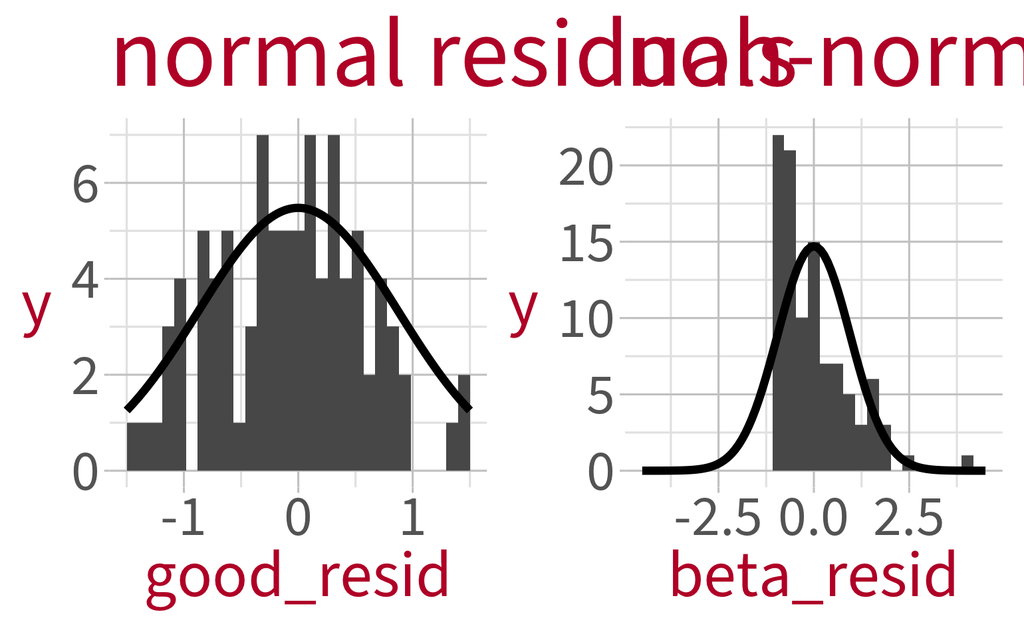

```r
resid_df <- tibble(
  good_resid = m_good$residuals,
  beta_resid = m_beta$residuals,
)

sd_good <- sd(m_good$residuals)
sd_beta <- sd(m_beta$residuals)

p_good_resid <- resid_df |>
  ggplot() +
  geom_histogram(aes(x = good_resid)) +
  geom_function(
    fun = function(x) dnorm(x, mean = 0, sd = sd_good) * 12,
    linewidth = 2) +
  xlim(-1.5, 1.5) +
  labs(
    title = 'normal residuals'
  ) +
  NULL

p_beta_resid <- resid_df |>
  ggplot() +
  geom_histogram(aes(x = beta_resid)) +
  geom_function(
    fun = function(x) dnorm(x, mean = 0, sd = .95) * 35,
    linewidth = 2
  ) +
  xlim(-4.5, 4.5) +
  labs(
    title = 'non-normal residuals'
  ) +
  NULL

p_good_resid + p_beta_resid
```

### q-q plot

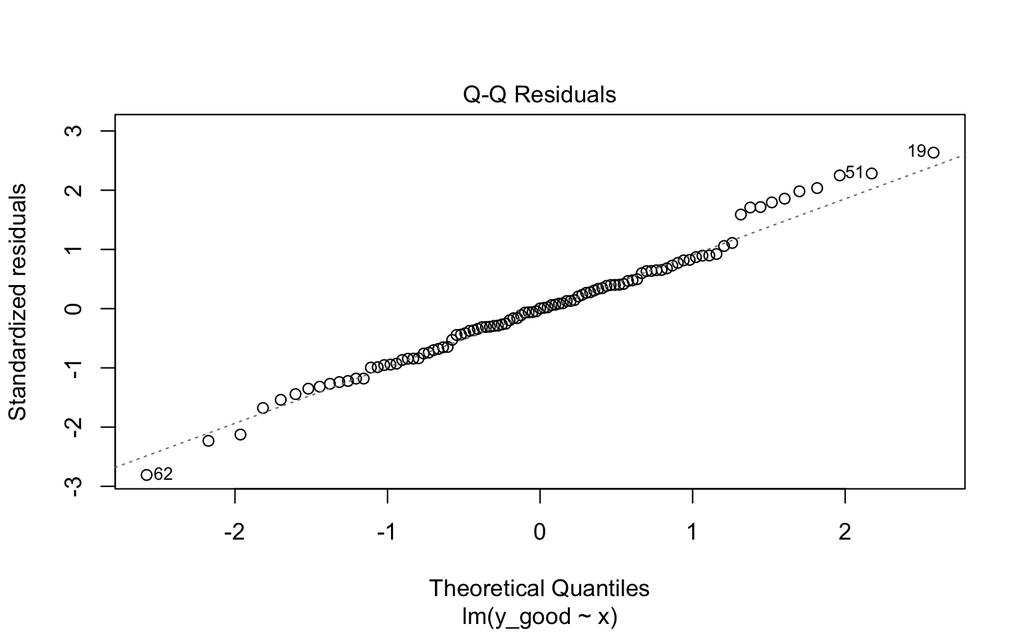

```r
plot(m_good, which = 2)
```

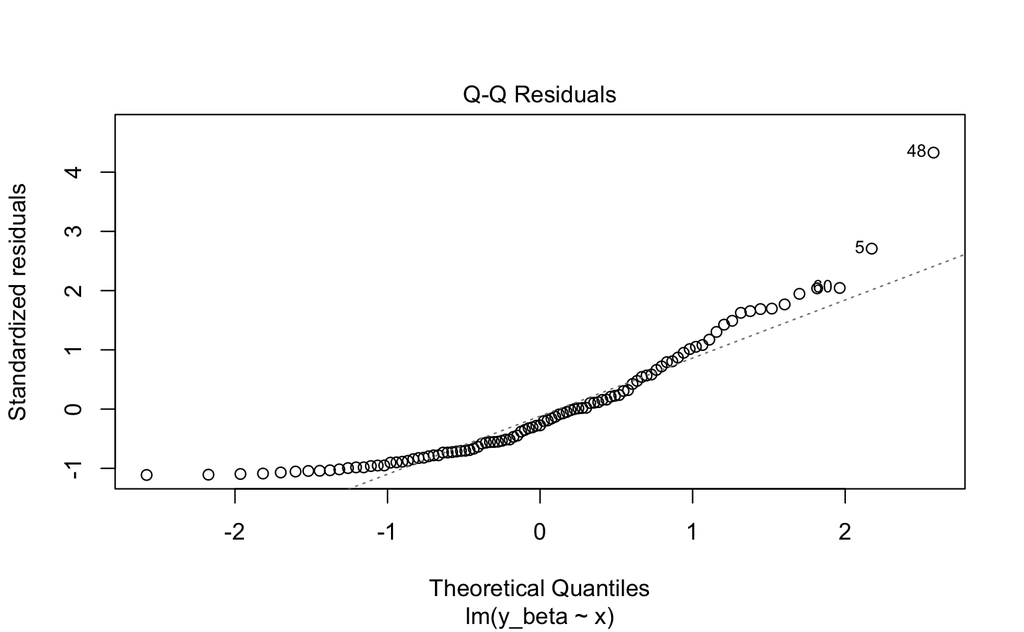

```r
plot(m_beta, which = 2)
```

## Simulate heteroscedasticity

Errors that increase with x

```r
set.seed(221020)

inc_error <- rnorm(101, mean = 0, sd = seq(0.1, 4, length.out = 101))

df <- tibble(
  x = seq(-2, 2, length.out = 101),
  y_good = abs(4 + (2 * x) + rnorm(101, 0, 1)),
  y_unequal = abs(4 + (2 * x) + inc_error),
)

p_unequal <- df |>
  ggplot(aes(x=x, y=y_unequal)) +
  geom_point() +
  geom_smooth(method = 'lm', se = FALSE) +
  NULL

p_good + p_unequal
```

```r
m_unequal <- lm(y_unequal ~ x, data = df)

car::residualPlot(m_unequal)  # same as plot() so idk if we need it
```

```r
plot(m_good, which = 1)
plot(m_unequal, which = 1)
```

# Diagnostics

## Three checks for unusual data points

Make sure single points aren’t driving the results.

### Outliers

Extreme values of y.

How quantify? Unexpectedly large (studentised) residuals.

#### Simulate

```r
set.seed(221020)

df <- tibble(
  x = seq(-2, 2, length.out = 101),
  y_good = abs(4 + (2 * x) + rnorm(101, 0, 1)),
  y_outl = abs(4 + (2 * x) + rnorm(101, 0, 1)),
)

df[95, 'y_outl'] <- 1.236227
df[98, 'y_outl'] <- 2.623973
df[30, 'y_outl'] <- 5.643033
df[20, 'y_outl'] <- 3.160261
df[14, 'y_outl'] <- 3.762352

p_outl <- df |>
  ggplot(aes(x=x, y=y_outl)) +
  geom_point() +
  geom_smooth(method = 'lm', se = FALSE) +
  NULL

p_good + p_outl
```

#### Check with studentised residuals

unstandardised residuals -> standardised residuals -> studentised residuals with `rstudent(model)`

```r
m_outl <- lm(y_outl ~ x, data = df)

df$stud_resid <- rstudent(m_outl)

df |>
  ggplot(aes(x = x, y = stud_resid)) +
  geom_point() +
  geom_hline(yintercept =  2, colour = 'red') +
  geom_hline(yintercept = -2, colour = 'red') +
  NULL

df |>
  filter(stud_resid > 2 | stud_resid < -2)
```

### High leverage

#### Simulate

```r
set.seed(221020)

df <- tibble(
  x = seq(-2, 2, length.out = 101),
  y_good = abs(4 + (2 * x) + rnorm(101, 0, 1)),
  y_levg = abs(4 + (2 * x) + rnorm(101, 0, 1)),
)



df <- rbind(
  df,
  tibble(
    x = c(3,
          4.5,
          -3.5),
    y_good = NA,
    y_levg = c(
      6.068172,
      12.201827,
      2.2368030)
  )
)

p_levg <- df |>
  ggplot(aes(x=x, y=y_levg)) +
  geom_point() +
  geom_smooth(method = 'lm', se = FALSE) +
  NULL

p_good + p_levg
```

#### Check with hat values

hat refers to the circumflex on top of a variable, which is like a little way of saying “this is an estimate from a model”. it’s like in natural language, like in French how a circumflex means “there used to be an ‘s’ here”. just an extra annotation.

`hatvalues()` is our workhorse here.

```r
# fit model
m_levg <- lm(y_levg ~ x, data = df)

# find mean expected hat value
n_predictors <- 1
n_observations <- nrow(df)
mean_hat <- (n_predictors+1)/n_observations

# points > 2*mean_hat will be considered high-leverage
df$hatvals <- hatvalues(m_levg)
df |>
  ggplot(aes(x = x, y = hatvals)) +
  geom_point() +
  geom_hline(yintercept = 2*mean_hat, colour = 'red')

# Plot good hat values
tibble(
  x = seq(-2, 2, length.out = 101),
  hatvals = hatvalues(m_good)
) |>
  ggplot(aes(x = x, y = hatvals)) +
  geom_point() +
  geom_hline(yintercept = 2*mean_hat, colour = 'red')
```

### High influence

#### Simulate

```r
set.seed(221020)

df <- tibble(
  x = seq(-2, 2, length.out = 101),
  y_good = abs(4 + (2 * x) + rnorm(101, 0, 1)),
  y_infl = abs(4 + (2 * x) + rnorm(101, 0, 1)),
)

# Use the same outlier values
df[95, 'y_infl'] <- 1.236227
df[98, 'y_infl'] <- 2.623973
df[30, 'y_infl'] <- 5.643033
df[20, 'y_infl'] <- 3.160261
df[14, 'y_infl'] <- 3.762352

# Add in the same high-leverage values
df <- rbind(
  df,
  tibble(
    x = c(3,
          4.5,
          -3.5),
    y_good = NA,
    y_infl = c(
      6.068172,
      12.201827,
      2.2368030)
  )
)

p_infl <- df |>
  ggplot(aes(x=x, y=y_infl)) +
  geom_point() +
  geom_smooth(method = 'lm', se = FALSE) +
  NULL

p_good + p_infl
```

#### Check with Cook’s distance

Cook’s distance is basically outlyingness * leverage. So it’s big if either one of those are true, and very big if both are true.

Interpretation: the average distance the predicted outcome values will move, if a given case is removed.

Possible thresholds:

- 1
- 4 / (sample_size - n_params - 1)
- relative to all Ds in the data set

```r
m_infl <- lm(y_infl ~ x, data = df)
df$D <- cooks.distance(m_infl)

df |>
  ggplot(aes(x = x, y = D)) +
  geom_point() +
  geom_hline(yintercept = 4 / (n_observations - n_predictors - 1), colour = 'red') +
  NULL

tibble(
  x = seq(-2, 2, length.out = 101),
  D = cooks.distance(m_good)
) |>
  ggplot(aes(x = x, y = D)) +
  geom_point() +
  geom_hline(yintercept = 4 / (101 - n_predictors - 1), colour = 'red')
```

```r
plot(m_infl, which = 4)
```

Check the outlier and leverage datasets too:

```r
plot(m_outl, which = 4)
plot(m_levg, which = 4)
```

#### Check with covariance ratio

Covariance ratio indicates the influence of a data point on the (co)variances of the regression parameters.

```r
df$cov.r <- covratio(m_infl)

covr_upper <- 1 + ((3 * (n_predictors + 1))/n_observations)
covr_lower <- 1 - ((3 * (n_predictors + 1))/n_observations)

df |>
  ggplot(aes(x = x, y = cov.r)) +
  geom_point() +
  geom_hline(yintercept = covr_upper, colour = 'red') +
  geom_hline(yintercept = covr_lower, colour = 'red') +
  NULL

tibble(
  x = seq(-2, 2, length.out = 101),
  cov.r = covratio(m_good)
) |>
  ggplot(aes(x = x, y = cov.r)) +
  geom_point() +
  geom_hline(yintercept = covr_upper, colour = 'red') +
  geom_hline(yintercept = covr_lower, colour = 'red') +
  NULL
```

It will detect weirdly high-influence points if they’re there, but it will also detect high-influence points regardless. Just because something exceeds these thresholds DOES NOT MEAN IT’S WEIRD OR COMES FROM A DIFF DISTRIBUTION/GENERATIVE PROCESS. This is why we need discretion.

### Check all these diagnostic measures at once with the function that does it all

```r
influence.measures(m_infl)
```

- `dfb.1_`: difference between the predicted values for the intercept with and without this observation
- `dfb.x`: difference between the predicted values for the slope with and without this observation <- there will be one of these per predictor
- `dffit`: difference between predicted values for the outcome with and without this observation
- `cov.r`: ratio of the covariance of regression parameters with and without this observation
- `cook.d`: Cook’s Distance of this observation
- `hat`: hat value of this observation

## Finally: one check for relationships between predictors

### Multicollinearity

#### Simulate

```r
set.seed(1)

n_obs <- 101
corr_x1y  <- 0.8
corr_x2y  <- 0.6
# corr_x1x2 <- 0.9  # vif = 5.3
corr_x1x2 <- 0.93   # vif = TBD

corr_df <- MASS::mvrnorm(
  n = n_obs,
  mu = c(0, 0, 0),
  Sigma = matrix(
    c(1, corr_x1y, corr_x2y,
     corr_x1y, 1, corr_x1x2,
     corr_x2y, corr_x1x2, 1),
    nrow = 3),
  empirical = TRUE
  )

colnames(corr_df) <- c('y', 'x1', 'x2')
corr_df <- as_tibble(corr_df)

pairs(corr_df)

corr_df |> as_tibble() |>
  ggplot(aes(x = x1, y = x2)) +
  geom_point()
```

```r
set.seed(1)

uncorr_x1x2 <- 0.0  # ideally this quantity would be low

uncorr_df <- MASS::mvrnorm(
  n = n_obs,
  mu = c(0, 0, 0),
  Sigma = matrix(
    c(1, corr_x1y, corr_x2y,
     corr_x1y, 1, uncorr_x1x2,
     corr_x2y, uncorr_x1x2, 1),
    nrow = 3),
  empirical = TRUE
  )

colnames(uncorr_df) <- c('y', 'x1', 'x2')
uncorr_df <- as_tibble(uncorr_df)

pairs(uncorr_df)

uncorr_df |>
  ggplot(aes(x = x1, y = x2)) +
  geom_point()
```

```r
corr_df |>
  ggplot(aes(x = x1, y = y, colour = x2)) +
  geom_point()

uncorr_df |>
  ggplot(aes(x = x1, y = y, colour = x2)) +
  geom_point()
```

#### Fit models

```r
m_corr <- lm(y ~ x1 + x2, data = corr_df)
summary(m_corr)
```

```r
m_uncorr <- lm(y ~ x1 + x2, data = uncorr_df)
summary(m_uncorr)
```

#### Check with VIF

```r
vif(m_uncorr)
```

```r
vif(m_corr)
```

<5 is low. between 5 and 10 is moderate. More than 10 is a big problem.

## Plots with `performance::check_model()`

Some of these assumptions/diagnostics can be checked en masse using `performance::check_model(model)`.

- posterior predictive check (basically uses the model to generate new fake data and compares that data to the observed data)
- assumption: linearity
- assumption: homogeneity of residual variance aka homosced
- diagnostics: influential observations
- diagnostics: collinearity
- assumption: normality of residuals

```r
check_model(m_good)
```

```r
check_model(m_beta)
```

```r
check_model(m_corr)
```

```r
check_model(m_infl)
```

```r
check_model(m_levg)
```

```r
check_model(m_outl)
```

```r
check_model(m_uncorr)
```

```r
check_model(m_unequal)
```